# Kpop Online Survey Participants So Far

Byunghwan Son (bson3@gmu.edu)

01/18/2022

As of January 2, 2022, there are 1,710 participants. Here are some demographic breakdowns. The total of 952 of them are either current US residents or those born in US, which is shown in Figure 1. There were quite a few ‘NA’ answers here–we want to exclude them from our analysis to be safe.

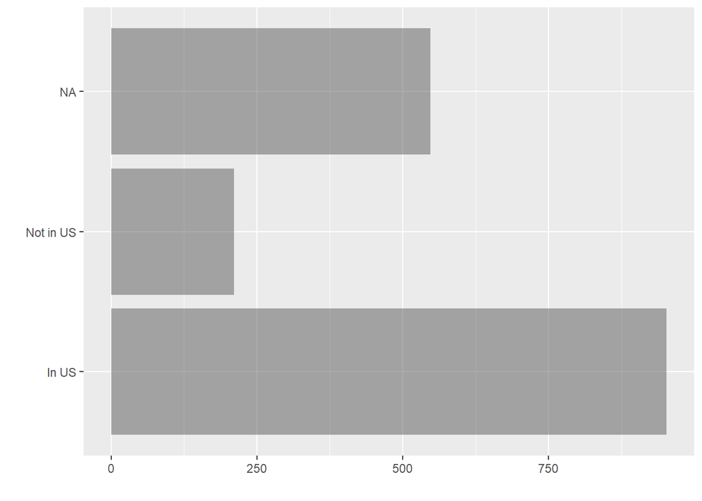

Figure 1: *US Participants*

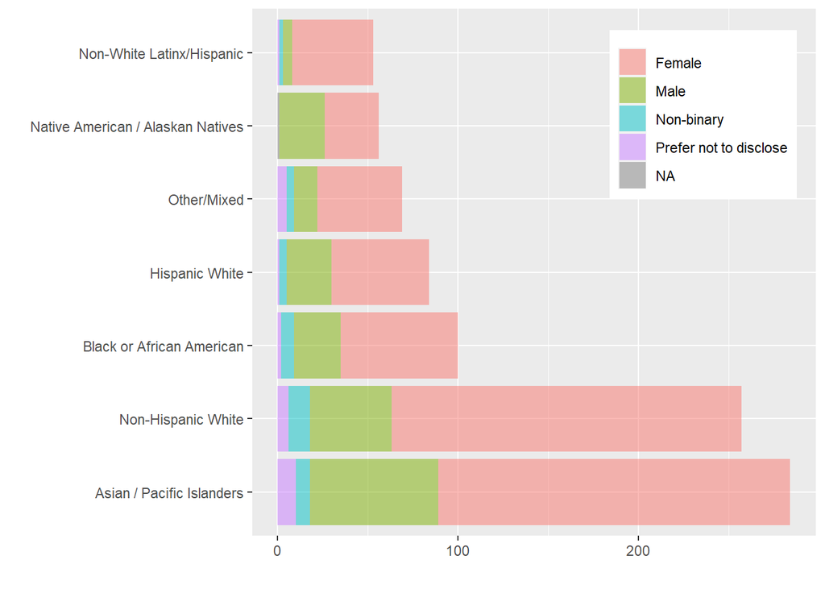

Figure 2: *Race/Gender breakdown, US participants*

Of the US residents, AAPI people are the relative majority (Figure 2). However, if we combine the Hispanic and non-Hispanic Whites together, it is in fact the Whites who are the majority. Consistent with other surveys, the fan populatio is predominantly female with a sizeable number of non-binary people. Non-White Latinx/Hispanic *male* fans seem to be **very** hard to come by.

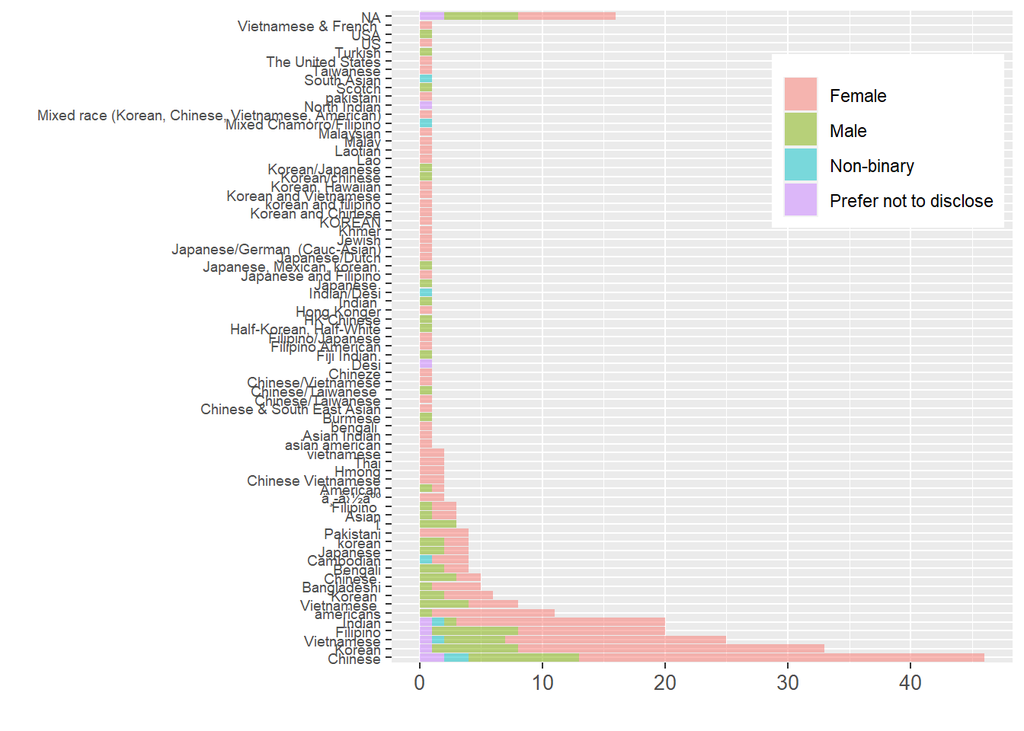

Figure 3: *Race/Gender breakdown, AAPI*

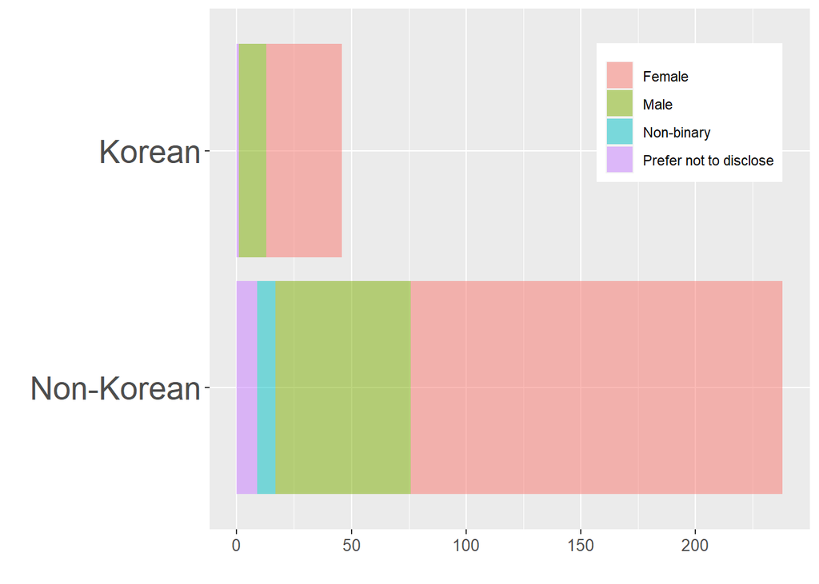

Figure 4: *Race/Gender breakdown, Korean vs. Non-Korean*

I also looked at the detailed makeup of the AAPI people. Three pretty obvious observations:

- Looking at Figure 3, the AAPI group is REALLY heterogeneous. Not only are there so many different ethnicities, people of mixed Asian heritages are not at all rare.
- Ethnic Koreans do not make the majority of AAPI. In fact, not even close. If we look at Figure 4, only about about 40 out of 200+ AAPI are of Korean heritage, mixed or otherwise.
- Male participants of ethnic Koreans are as scarce as those of other ethnicities.

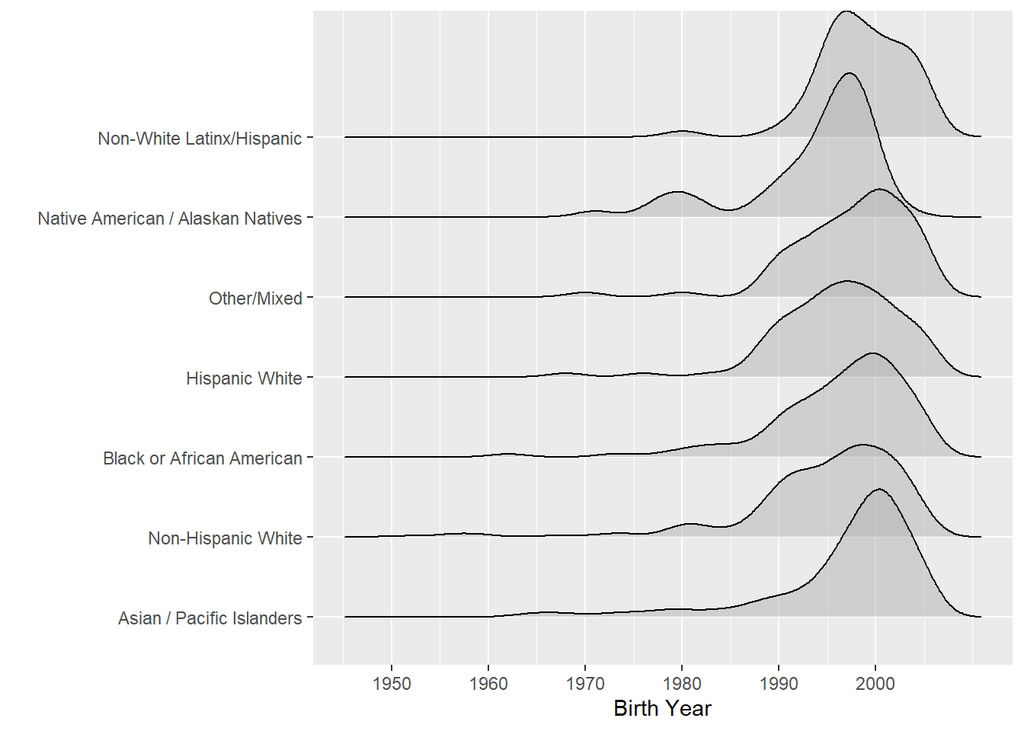

Figure 5: *Age Distribution*

The distribution of age seems pretty similar across racial groups (Figure 5). But we do have pretty healthy distributions here, meaning that they are not overly concentrated on college-age groups. The distributions of non-White Hispanic and Native Americans might seem a bit different, but that’s really the function of a very small number of participants in those categories.

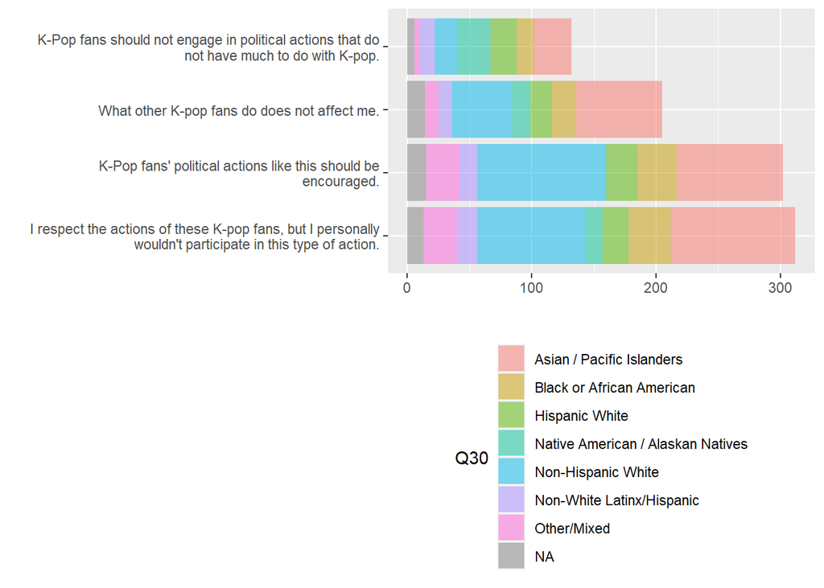

Figure 6: *Tulsa Trump Rally Prank*

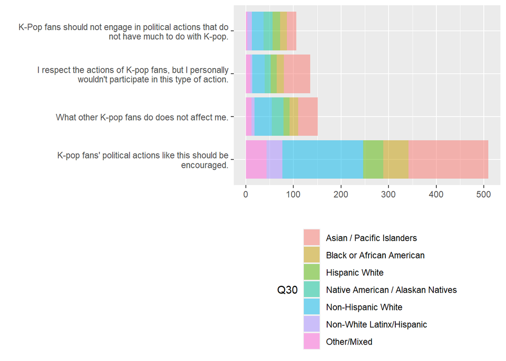

Figure 7: *BLM*

Looking at the political opinions of Kpop fans in the US, an interesting pattern emerges. When asked about the Tulsa Trump Rally Prank (Figure 6), quite a few people seem to distant themselves from the activists, saying they wouldn’t participate in pulling such a prank themselves. A non-negligible number of people also seem to have the position of “it doesn’t matter to me.” When it comes to BLM (Figure 7), however, the great majority of the participants lean supportive of the movement in the name of the Kpop fandom. Ascertaining the reason why would need more analysis, but several possibilities would be:

1. the word ‘prank’ has a negative connotation (or signaled the lack of seriousness) and pushed people to be more reserved about it;
2. social conformity biased might kick in given how widely BLM is accepted;
3. or people are reluctant to identify with explicitly partisan actions (Tulsa prank).

As for the attitudes toward the BLM movement, do K-pop fans’ ideologies play a role here? Figure 9 plots the mean ideology score of US K-pop fans (“K-pop fans are generally progressive/liberal as opposed to being conservative”) for each category of the fan attitudes toward BLM. Not surprisingly, the fans who strongly espouse fan participation in BLM are likely to be those who view peer K-pop fans as progressive. *We are progressives and we should be more involved in BLM* – in a nutshell. This is a statistically significant difference. For comparison, I also plotted a similar relationship for the Tulsa Prank (8). The result is quite similar–the ones who believe that fans should be more involved in this kind of political actions tend to believe that the fandom is more progressive. Given that there is much weaker overall support for the activism in the Tulsa case, it seems that the attitudinal difference between BLM and Tulsa is not much related to the whether fandom is viewed as progressive (will look into this more at the individual level later).

Note, though, this does not necessarily mean that only those who think K-pop fans are progressive endorse fans’ involvement in BLM. K-pop-fans in the US *in general* tend to see their peers as progressive. Those who are ambivalent about Kpop-BLM activism (‘not affect’ and ‘respect-but’) are not too far off from the average level of ideology score (vertical dashed line). Even the ones who do not approve of the activism (‘should not engage’) still see the overall fandom as progressive (about 6.4) which is not statistically different from those of the ambivalent positions. It can mean many different things, but an immediate implication is that while pro-BLM fans are more likely than others to see the fandom as progressive, a lot of fans who think the fandom is progressive do not endorse the fandom’s progressive activism, which can be perhaps a source of individual discontent.

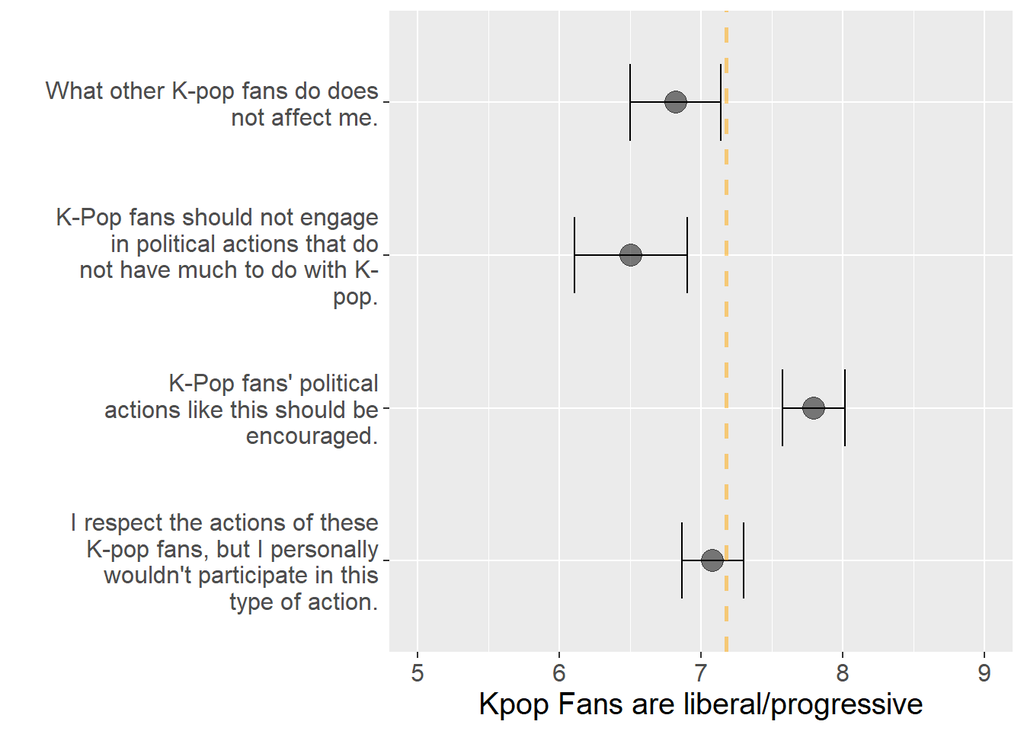

Figure 8: *Tulsa Prank and Peer Ideology*. Circles are point estimates. Error bars represent the 95% confidence intervals. The vertical dashed line indicates the sample mean of the fan ideology variable.

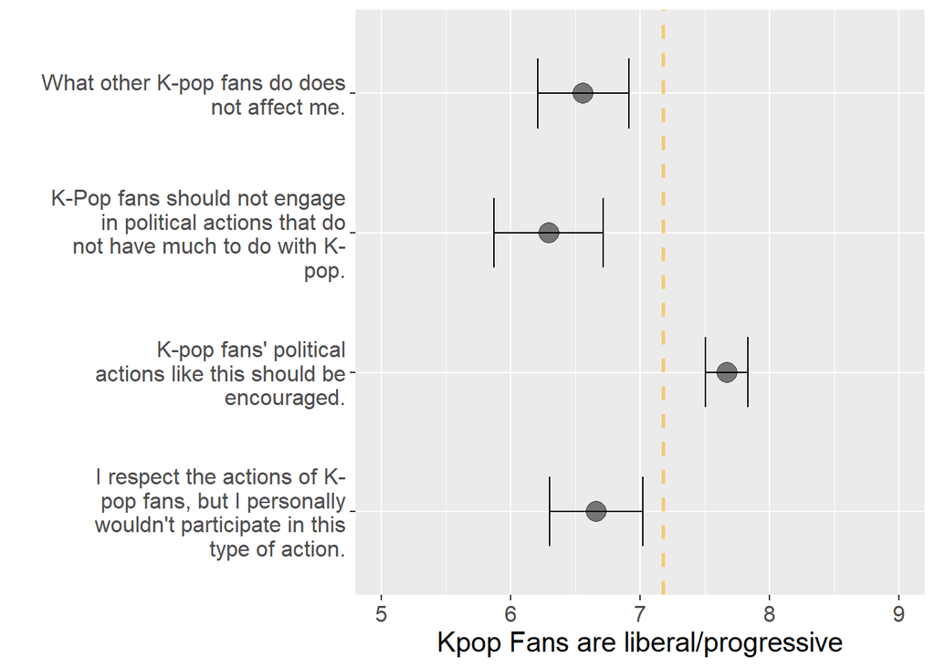

Figure 9: *BLM and Peer Ideology*. Circles are point estimates. Error bars represent the 95% confidence intervals. The vertical dashed line indicates the sample mean of the fan ideology variable.

I think there’s some behavioralist literature for each of these three. Another thing to note is that there doesn’t seem to be much of racial variations here.

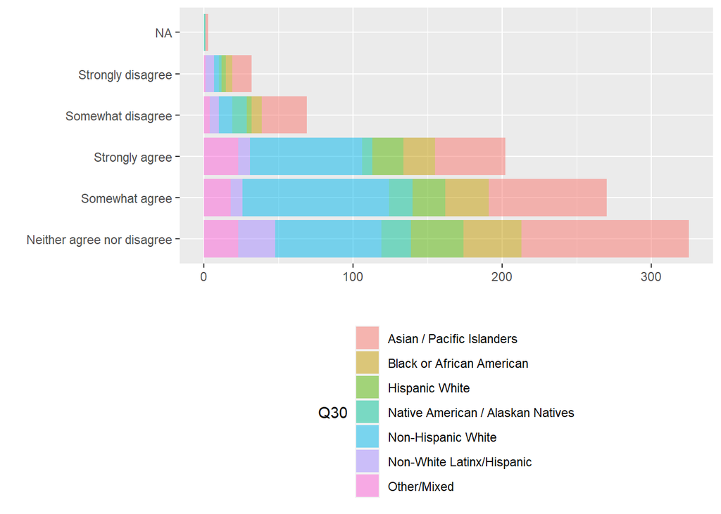

Figure 10: *K-pop has changed my views of Korea and Koreans in a positive way.*

## International Comparison? Note that the international sample is substantially smaller.

Another thing to look at – how do Non-US fans react to the political actions of fellow Kpop-fans in the US? Are they the same? Well, it seems that they kind of are as the different seems to be rather marginal (11).

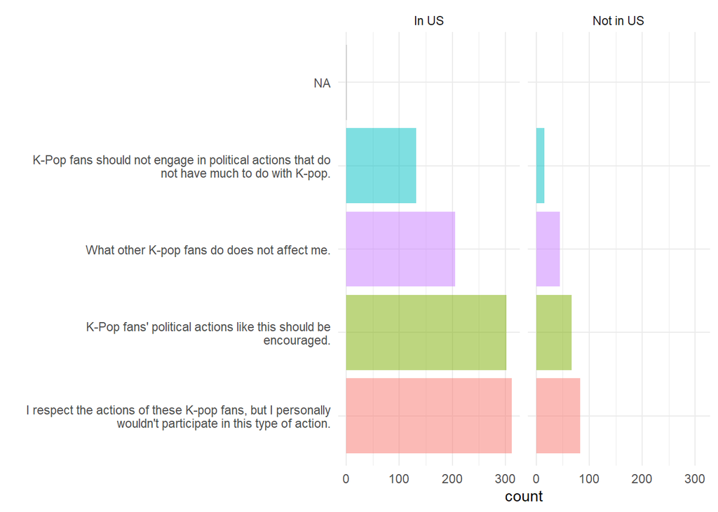

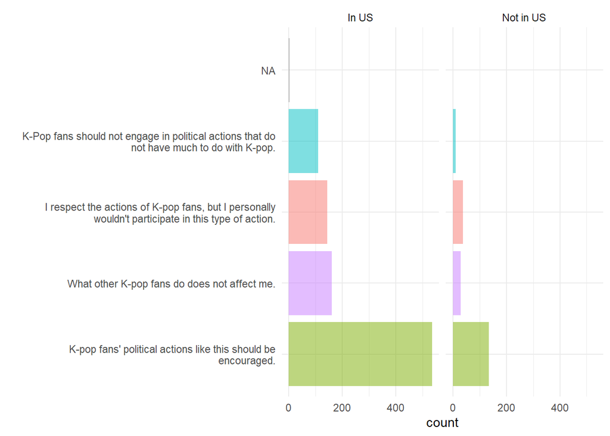